# Day_2 slides

## Introduction to

[figure not shown]

### with Application to Bioinformatics

#### - Day 2

## Yesterday's Key Takeaways

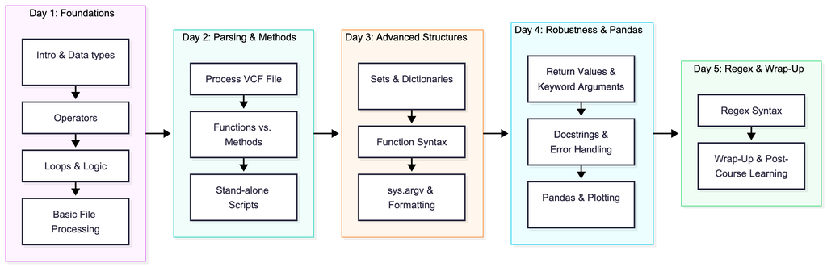

- Liternals, variables
  - Liternal: `3.14`, `"fruites"`
  - Variable: `dna`, `myVar`
  - Basic data types: `Numeric`, `String`, `Boolean`, `None` and `Collection`
- Built-in functions and operations
  - `print`, `max`, `sum`, `+`
- Loops
  - `for` loop and `while` loop
- Use `if/elif/else` statements to control the logic of the code
- Read and write data from/to file
  - `open(filename, "r")` or `open(filename)`
  - `open(filename, "w")`

## Day 2

- **Session 1**
  - Quiz: Review of Day 1
  - Lecture: Go through the quiz and review the key concepts
- **Session 2**
  - Lecture: Variants identification with VCF
  - Ex1:
  - PyQuiz 2.1
- **LUNCH**
- **Session 3**
  - Lecture: Functions and Methods
  - Ex2: continuation of Ex1
- **Session 4**
  - Standalone Python script
  - PyQuiz 2.2
  - Ex3: IMDb
- **Project time**

## Quiz: Review Day 1

Go to Canvas, `Modules -> Day 2 -> Review Day 1`

**Questions can be multiple-choice**

~20 minutes

## Q1 & Q2: Variables and Types

#### Q1. Which of the following is of the type `float`?:

```
7.4
```

#### Q2. Match the following variables with their type:

```
var1 = 54                 # integer
var2 = [1,2,7,1,24]       # list
var3 = 2.98               # float
var4 = True               # boolean
```

### Literals and variables

- A literal is the **actual value itself**
- A variable is a **named container** that holds or points to a value

```python
"ATGCGTAC" # string
8 # integer
3.14 # float
True # boolean
```

```python
s = "ATGCGTAC"
a = 8
b = 3.14
c = True
```

```python
# Use meaningful variable names !!
dna_sequence = "ATGCGTAC"
sequence_length = len(dna_sequence)
print("length of", dna_sequence, "is", sequence_length)
```

### Lists

A collection of values.

```python
x = [1,5,3,7,8]
y = ['a','b','c']
print(type(y))
# print(x + y) # a list can have heterogenous data types
```

## Q3: Comments

#### Which of the following symbols can be used to write comments in your code?

```
#
```

You can also use docstring `"""` to comment out multiple lines of code, although it is not designed for that.

```python
"""
This is a description
of the code below
"""
li = ["abc"] * 10
print(li)
```

## Q4 - Q6: Operations

#### Q4. What happens if you do `[1,2,5,11] + [87,2,43,3]`?

`[1,2,5,11,87,2,43,3]` The lists will be concatenated

#### Q5. How do you find out if the variable `x` is present in a the list `mylist`?

Two correct answers:

```
x in mylist
```

```
for l in mylist:
    if l == x:
        print('Found a match')
```

#### Q6. How do you find out if 5 is larger than 3 and the integer 4 is the same as the float 4? Fill in all the missing code.

```
5 > 3 and 4 == 4.0
```

```
5 > 3 and 4 == float(4)
```

```python
a = 0.1+0.2
b = 0.3
print(a == b)
```

```python
# Unsafe:
print(a == b)  # False

# Safe:
import math
print(math.isclose(a, b))  # True
```

### Basic operations

**Type Operations**

int + - * / ** % // ...  
float + - * / ** % // ...  
string + *

```python
i = 2
f = 5.46
li1 = [1,2,3,4]
li2 = [5,6,7,8]
```

```python
i * f
```

```python
li1 * i
```

```python
li1 * f # does this operation work?
```

### Comparison/Logical/Membership operators

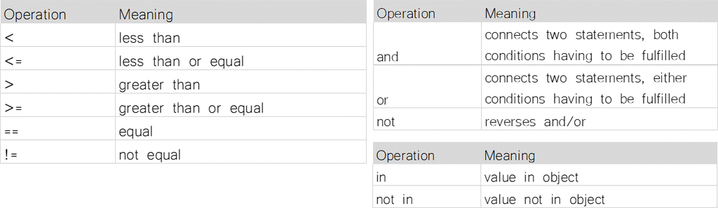

```python
li = [1,2,3,4,5,6,7,8]
b = 5
b in li
```

```python
b not in li
# not b in li # works as well, but not recommended
```

```python
c = 10
b < c or c == 1
```

### Python Operator Precedence (Highest → Lowest)

| Priority | Operator Category | Operators | Notes |
| --- | --- | --- | --- |
| **1** | **Parentheses** | `( )` | Force order of evaluation |
| **2** | **Exponentiation** | `**` | Right-associative |
| **3** | **Unary operators** | `+x`, `-x`, `~x` | Act on one operand |
| **4** | **Multiplicative** | `*`, `/`, `//`, `%` | Multiply/divide/modulo |
| **5** | **Additive** | `+`, `-` | Addition and subtraction |
| **6** | **Bitwise shifts** | `<<`, `>>` | Shift bits left/right |
| **7** | **Bitwise AND** | `&` |  |
| **8** | **Bitwise XOR** | `^` |  |
| **9** | **Bitwise OR** | `\\|` |  |
| **10** | **Comparisons** | `==`, `!=`, `<`, `<=`, `>`, `>=`, `is`, `is not`, `in`, `not in` | Chainable |
| **11** | **Boolean NOT** | `not` | Unary boolean |
| **12** | **Boolean AND** | `and` |  |
| **13** | **Boolean OR** | `or` |  |

**For beginners, use paretheses () if you are unsure**

More details: https://www.w3schools.com/python/python_operators_precedence.asp

## Q7-Q9: Sequences and collections

#### Q7. How do you select the second element in the variable `mylist = [4,3,8,10]`?

Lists (and strings) are an ORDERED collection of elements where every element can be access through an index.

```
value:           4    3    8    10
index:           0    1    2    3
index(negative) -4   -3   -2   -1
```

```python
mylist = [4,3,8,10]
mylist[1]
```

## Q8: Mutable / Immutable sequences and iterables

Lists are mutable object, meaning you can use an index to change the list, while strings are immutable and therefore not changeable.

```python
li1 = ['a','b','c']       # mutable
str1 = 'abc'              # immutable
```

```python
li1[2] = 'B'
li1
```

```python
str1[2] = 'B'
```

## Q9: Which of the following types are iterable?

An iterable sequence is anything you can loop over, ie, lists and strings.

- **lists**
- ingegers
- float
- **strings**
- booleans

## Data type: `tuples`

- A tuple is almost like a list but an immutable sequence of objects
- Elements can NOT be changed in a tuple by using its index
- Still iterable

```python
myTuple = (1,2,3,4,'a','b','c')
myList = [1,2,3,4,'a','b','c']
```

```python
for item in myTuple:
    print(item)
```

```python
for item in myList:
    print(item)
```

```python
myList[2] = 42
myList
```

```python
myTuple[2] = 42
```

## What is the benefit of `tuple`

- Immutability ensures data integrity and safety, in the use cases when data should be kept unchanged during processing
- Use less memory than `list`, better performance

## Q10: If/ Else statements

#### How do you do to print ‘Yes’ if x is bigger than y?

```
if x > y:
    print('Yes')
```

```python
# elif
```

## Q11-Q12: Files and loops

#### Q11: How do you open a file handle to read a file called ‘somerandomfile.txt’?

```
fh = open('somerandomfile.txt')
```

#### Q12: The file in the previous question contains several lines, how do you print each line, with or without trailing whitespace?

```
for line in fh:
    print(line)
```

```
for row in fh:
    print(row.strip())
```

```python
fh = open('../files/somerandomfile.txt','r', encoding = 'utf-8')
for line in fh:
    print(line.strip())
fh.close()
```

```python
# while loop
key = ""
while key != "python2026":
    key = input("Enter your key: ")

print("Correct key!")
```

# Questions?

# Break (10 min)

## Session 2

- Lecture: **Variants identification with VCF**
- Ex1
- PyQuiz 2.1

## Lunch

## Variants identification with VCF

- A VCF (Variant Call Format) file is a text file format used in bioinformatics for storing gene sequence variations.

## Description of the task

You have a VCF file (`genotypes_small.vcf`, which can be found in the `downloads` folder) with a number of samples. You are interested in only one of the samples (**sample1**) and one region (**chr5, 1,200,000-1,300,000**, including the start and end positions). What you want to know is whether this sample has any variants in this region, and if so, which variants.

### What is your input?

1. **CHROM**: 1 (Chromosome 1)
2. **POS**: 10177 (Position 10177 on the chromosome, **starting from 1**)
3. **ID**: rs367896725 (Reference SNP ID)
4. **REF**: A (Reference allele is A)
5. **ALT**: AC (Alternative allele is AC)
6. **QUAL**: 50 (Quality score)
7. **FILTER**: PASS (status, meaning passed all quality control)
8. **FORMAT**: GT:DP:CB (Genotype, Depth, Cell Barcode)
9. **SAMPLES**: 0/1:30:SM (Sample genotypes and additional info)

### Genotype field

`0/1`

- For human, and many other organisms, there are two copies of genetic information, inherited from both parents.
- `0` means DNA at this position is the same as reference allele (`A`),
- `1` means has alternative allele, in this case `AC`

**The notation of alternative allele is not always `1`**: `0/2`

## Some terminologies

| Genotype | Status | Meaning |
| --- | --- | --- |
| **0/0** | Homozygous Reference (wild type) | Two copies of the reference allele. |
| **0/1** or **1/0** | Heterozygous | One copy of the reference allele and one copy of the alternate allele. |
| **1/1** | Homozygous Alternate | Two copies of the alternate allele. |

## Start with pseudocode!

- Pseudocode is a description of what you want to do without actually using proper syntax

### Task:

You have a VCF file with a number of samples. You are interested in only one of the samples (sample1) and one region (chr5, 1,200,000-1,300,000, including the start and end positions). What you want to know is whether this sample has any variants in this region, and if so, which variants.

- Open the file and loop over lines (ignore lines with started with `#`)
- Identify lines where chromosome is equal to `5` and position is between 1,200,000 and 1,300,000
- Isolate the column that contains the genotype for sample1, e.g. `0/1:30:SM`
- Extract only the genotypes (e.g. `0/1`) from the column
- Check if the genotype contains any alternate alleles, i.e., if not `0/0`.
- Print any variants containing alternate alleles for this sample between specified region

#### Open the file and loop over lines (ignore lines starting with `#`), and print the first record

```python
vcf_file = '../downloads/genotypes_small.vcf'
with open(vcf_file, 'r', encoding='utf-8') as fh:
    for line in fh:
        if not line.startswith('#'):
            line = line.strip()
            print(line)
            break
# Next, find chromosome 5
```

#### Identify lines where chromosome is `5`

```python
vcf_file = '../downloads/genotypes_small.vcf'
with open(vcf_file, 'r', encoding='utf-8') as fh:
    for line in fh:
        if not line.startswith('#'):
            line = line.strip()
            cols = line.split('\t')
            chrom = cols[0]
            if chrom == '5':
                print(cols)
                break

# Next, find the correct region, between 1,200,000 and 1,300,000
```

#### Identify lines where chromosome is `5` and position is between `1,200,000` and `1,300,000`

```python
vcf_file = '../downloads/genotypes_small.vcf'
with open(vcf_file, 'r', encoding='utf-8') as fh:
    for line in fh:
        if not line.startswith('#'):
            line = line.strip()
            cols = line.split('\t')
            chrom = cols[0]
            pos = int(cols[1])
            if chrom == '5' and (1200000 <= pos <= 1300000):
                print(cols)
                break
# Next, find the genotypes for sample1
```

#### Isolate the column that contains the genotype for sample1

```python
vcf_file = '../downloads/genotypes_small.vcf'
with open(vcf_file, 'r', encoding='utf-8') as fh:
    for line in fh:
        if not line.startswith('#'):
            line = line.strip()
            cols = line.split('\t')
            chrom = cols[0]
            pos = int(cols[1])
            if chrom == '5' and (1200000 <= pos <= 1300000):
                gt_field = cols[9]
                print(gt_field)
                break

# Next, extract the genotypes only
```

#### Extract only the genotypes from the column

```python
vcf_file = '../downloads/genotypes_small.vcf'
with open(vcf_file, 'r', encoding='utf-8') as fh:
    for line in fh:
        if not line.startswith('#'):
            line = line.strip()
            cols = line.split('\t')
            chrom = cols[0]
            pos = int(cols[1])
            if chrom == '5' and (1200000 <= pos <= 1300000):
                gt_field = cols[9]
                gt = gt_field.split(':')[0]
                print(gt)
                break

# Next, find in which positions sample1 has alternate alleles
```

#### Check if the genotype contains any alternate alleles

```python
vcf_file = '../downloads/genotypes_small.vcf'
with open(vcf_file, 'r', encoding='utf-8') as fh:
    for line in fh:
        if not line.startswith('#'):
            line = line.strip()
            cols = line.split('\t')
            chrom = cols[0]
            pos = int(cols[1])
            if chrom == '5' and (1200000 <= pos <= 1300000):
                gt_field = cols[9]
                gt = gt_field.split(':')[0]
                if gt != "0/0": # For robust VCF processing
                                # this condition should account
                                # for phased and missing data
                                # (e.g., 0|0, ./. ).
                    print(gt)
#Next, print nicely
```

#### Print any variants containing alternate alleles for this sample between specified region

```python
vcf_file = '../downloads/genotypes_small.vcf'
with open(vcf_file, 'r', encoding='utf-8') as fh:
    for line in fh:
        if not line.startswith('#'):
            line = line.strip()
            cols = line.split('\t')
            chrom = cols[0]
            pos = int(cols[1])
            if chrom == '5' and (1200000 <= pos <= 1300000):
                gt_field = cols[9]
                gt = gt_field.split(':')[0]
                if gt != "0/0": # For robust VCF processing this condition should account for phased and missing data (e.g., 0|0, ./. ).
                    ref = cols[3]
                    alt = cols[4]
                    info = chrom + ":" + str(pos) + "_" + ref + "-" + alt + " has genotype: "+ gt
                    print(info)
```

## Exercise 1

Go to Canvas -> Moudles -> Exercises Day 2

#### Three options

1. Green exercise
2. Yellow exercise
3. Red exercise

The level of complexity increases with each exercise

- AI-Assisted Coding exercise

New to programming: Do Green exercise and possibly Yellow exercise + AI-Assisted Coding exercise  
More experienced: Do Yellow exercise and/or Red exercise + AI-Assisted Coding exercise

### The exercise will be continued in the afternoon

## **Session 3**

- Lecture: **Functions and Methods**
- Ex2:

### What is a function

- A function is a block of code that performs a specific task.
- It can take input (parameters) and return output (results).
- Functions help to reuse code and make programs more modular and readable.
- With a function, you only need to know how to use it, but not how it's implemented.

```python
print("this is your sequence")
```

```python
sorted([5,3,135,31])
```

```python
sum([1,2,3,4,5])
```

### What is a method

- A method is a function that is associated with objects (instances of class)
  - All data types in Python are objects

```python
"   I'm a line with trailing spaces  ".strip()
```

```python
"   I'm a line with trailing spaces  ".split()
```

```python
li = [3, 1, 5, 43, 5]
li.sort()
print(li)
```

### What does it matter to me?

For now, you only need to know the different syntaxes of using a function and a method and how to use them

**A function:**  
`functionName(arg1, arg2)`

**A method:**  
`obj.methodName()`

### Python built-in functions:

https://docs.python.org/3/library/functions.html

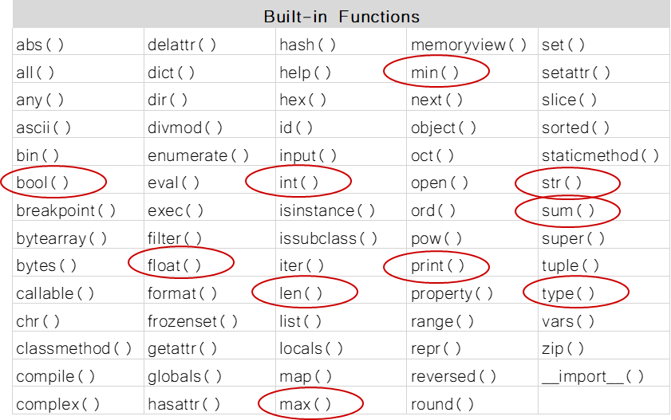

### Introduction to some useful functions

#### `help`

```python
help(max)
```

```python
a = 5
help([1,2,3])
```

### `range`

```python
for i in range(5):
    print(i)
```

```python
# range(start, stop, step)
# generate a series of odd number
for i in range(1, 10, 2):
    print(i)
```

```python
# negative step
for i in range(10, 1, -2):
    print(i)
```

#### Strictly speaking, range is not a function, instead, it is a built-in class

```python
print(type(range))
print(type(sum))
```

### `sorted`

```python
li = [5, 4, 1, 3, 10, 13, 13]
print(sorted(li))
```

```python
print(sorted(li, reverse=True))
```

```python
# sorted does not change the content in place
li = [5, 4, 1, 3, 10, 13, 13]
print(sorted(li))
print(li)
sorted_li = sorted(li)
print(li)
```

### `dir`:

return a list of names comprising the attributes of the given object

```python
dir(str)
```

```python
a = "This is an ongoing course".strip().split().index('an')
dir(a)
```

### Some userful methods for Strings

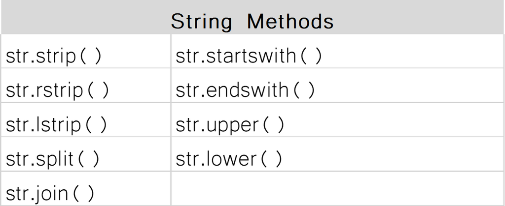

#### `str.split()`

```python
a = '  split a "string into a list" '
a.split()
```

```python
a.split(maxsplit=2)
```

#### `str.lstrip()`

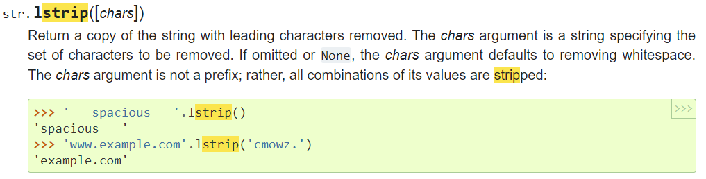

```python
line = "TAG:here comes the actual content"
line.lstrip("TAG:")
print(line.lstrip("TAG"))
print(line) # the content of line is not changed in place
```

```python
line = "AB:A:B should not be removed"
line.lstrip("AB:") # The chars argument is not a prefix
```

```python
line.removeprefix("AB:")
```

#### `str.join`

```python
','.join(["ATGC", "CCCCC", "AAATG", "CTTTGTA"]) # convert a list to string separated by comma ','
```

### Some userful methods for Lists

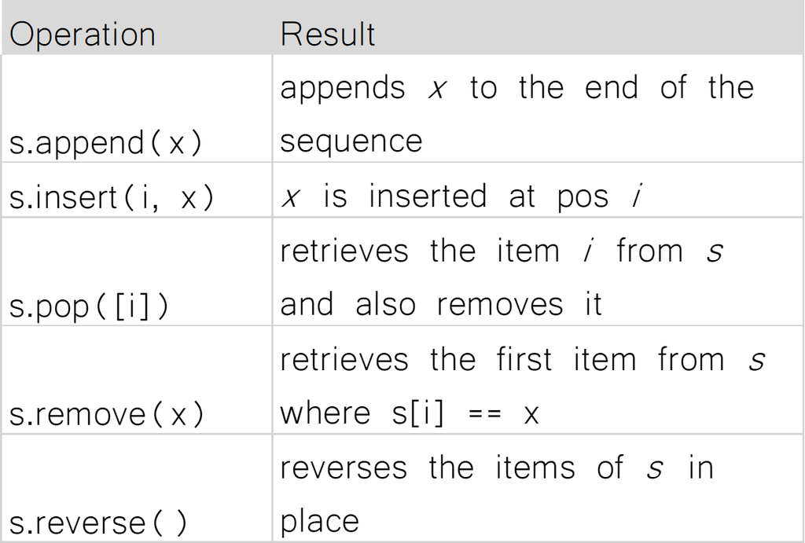

```python
a = [1, 2, 5, 6, 7, 5, 7, 8]
a.append(9)
a
```

```python
a.pop()
a
```

```python
a.pop(1) # pop(index)
a
```

```python
a.reverse()
a
```

```python
a.remove(5) # remove(value)
a
```

```python
a.insert(0, 13)
a
```

```python
### Tuples are immutable
a = (2, 3, 4, 15)
a.pop()
```

## Summary

- Tuples are immutable sequences of objects
- Plan your approach before you start coding
- A method always belongs to an object of a specific class, a function does not have to
  - call a function by `functionName(args)`
  - call a method by `obj.methodName(args)`
- The official Python documentation describes the syntax for all built-in functions and methods
  - https://docs.python.org/3/
  - https://www.w3schools.com/python/

## Exercise 2 (continuation of Ex1)

### Three options

1. Green exercise
2. Yellow exercise
3. Red exercise

The level of complexity increases with each exercise.

- AI-Assisted Coding exercise

New to programming: Do Green exercise and possibly Yellow exercise + AI-Assisted Coding  
More experienced: Do Yellow exercise and/or Red exercise + AI-Assisted Coding

## Session 4

- Lecture: **Standalone python script**
- PyQuiz 2.2!
- Ex3

### Project time

## Python script

A Python script is a file containing Python code that can be executed all at once.

- File Extension: `.py`

```python
vcf_file = '../downloads/genotypes_small.vcf'
with open(vcf_file, 'r', encoding='utf-8') as fh:
    for line in fh:
        if not line.startswith('#'):
            line = line.strip()
            cols = line.split('\t')
            chrom = cols[0]
            pos = int(cols[1])
            if chrom == '5' and (1200000 <= pos <= 1300000):
                gt_field = cols[9]
                gt = gt_field.split(':')[0]
                if gt != "0/0": # For robust VCF processing this condition should account for phased and missing data (e.g., 0|0, ./. ).
                    ref = cols[3]
                    alt = cols[4]
                    info = chrom + ":" + str(pos) + "_" + ref + "-" + alt + " has genotype: "+ gt
                    print(info)
```

#### Now we will save the code in a text file and try to run it in the terminal

### About the file extension `.py`

- Actually a Python script can have any extention or even without an extension.
- We use it as a convention
- Other benefits of using the `.py` entension - people and the OS can recognize it.

### Things to remember when working with scripts

- Put *#!/usr/bin/env python* in the beginning of the file
- Make the file executable to run with `./script.py`
- Otherwise run script with `python script.py`

## 5 mins exercise

Put some of your Python code you have written so far and save it in a Python script, run it in a terminal with

```
    python yourscript.py
```

- Replace `yourscript.py` with the actual name you use

## PyQuiz 2.2

Go to Canvas, `Modules -> Day 2 -> PyQuiz 2.2`

## Exercise with IMDb

Go to Canvas, `Modules -> Day 2 -> IMDb exercise - day 2`

## IMDb

Get the file `250.imdb` from the download folder (https://raw.githubusercontent.com/NBISweden/workshop-python/ht26/downloads.zip)

The format of this file is:

- Line by line
- Columns separated by the | character
- Header starting with #

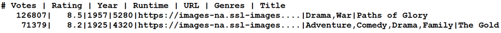

# Votes | Rating | Year | Runtime | URL | Genres | Title

### Task: Find the movie with the highest rating

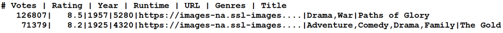

Write step-by-step pseudocode

- Open file
- Initiate counter to keep track of highest rating and movie. Start counter at 0
- Loop over all lines not starting with '#'
- Strip and split the lines into a list
- Save the element containing the rating from the list into a variable
- If current rating is higher than the rating in the counter, replace counter value with rating and movie
- Close file
- Print counter